# Analysis of First Pass Regressions Out

Henrik Singmann

01 August, 2017

```r
require(dplyr)
require(tidyr)
require(stringr)
require(ggplot2)
require(afex)
require(lattice) # for qqmath
require(gridExtra)
theme_set(theme_minimal())
require(optimx)
require(DHARMa) # for residual analysis
#require(binom)
require(effects)
```

# Introduction

The goal of the following analysis was to see whether the explanatory goodness of fit would affect the DVs. For detailed analysis of the IVs see other file.

```r
data_in <- read.csv("RO_plus_ratings.csv")
data_in$P.s <- factor(data_in$P.s)
data_in$Item <- factor(data_in$Item)
```

# First pass Regression Outs

## Data Preparation

```r
drp_r <- droplevels(data_in[data_in$Item != "9" ,])
nas <- is.na(drp_r$spillover) | is.na(drp_r$Consequent)
drp_r <- droplevels(drp_r[!nas,])
```

For the analysis we remove 0 trials with missing data in either spillover or Consequent. Then we z-transform the continuous `Accepts` variable.

```r
drp_r <- drp_r %>%
  mutate(
    acc_z = (Accepts - mean(Accepts))/sd(Accepts))
    #conf_z = (Confident- mean(Confident))/sd(Confident))
```

# Consequent

Note that the maximal model for models including `Fit` have random slopes for `Fit` for both random effects grouping factors (i.e., participant `P.s` and `Item`). For models including the continuous fit measure `Accepts` we have by-participant random slopes for `Accepts`, but by-item random slopes for `Fit` (as `Accepts` has only two different values for each `Item`, using the binary `Fit` variable seems more reasonable.)

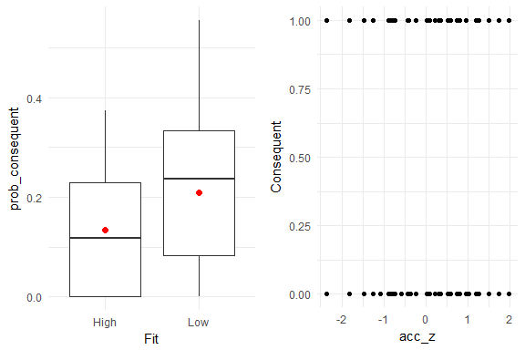

```r
agg <- drp_r %>%
  group_by(P.s, Fit) %>%
  summarise(prob_consequent = mean(Consequent),
            prob_spillover = mean(spillover),
            consequent = sum(Consequent),
            spillover = sum(spillover),
            n = n()) %>%
  ungroup
p_obs_acc <- ggplot(data = drp_r, aes(x = acc_z, y = Consequent)) +
  geom_point()
p_obs_fit <- ggplot(agg, aes(x = Fit, y = prob_consequent)) +
  geom_boxplot() +
   stat_summary(fun.y = "mean", colour = "red", size = 2, geom = "point")
grid.arrange(p_obs_fit, p_obs_acc, ncol = 2)
```

## With Fit

```r
m_con_f_1 <- mixed(Consequent ~ Fit + (Fit|P.s) + (Fit| Item), drp_r, family = binomial, method = "LRT", progress = FALSE)
```

```
Contrasts set to contr.sum for the following variables: Fit, P.s, Item
Model failed to converge with max|grad| = 0.0010748 (tol = 0.001, component 1)
```

```r
summary(m_con_f_1)
```

```
Generalized linear mixed model fit by maximum likelihood (Laplace Approximation) ['glmerMod']
 Family: binomial  ( logit )
Formula: Consequent ~ Fit + (Fit | P.s) + (Fit | Item)
   Data: drp_r

     AIC      BIC   logLik deviance df.resid
   375.5    407.6   -179.8    359.5      400

Scaled residuals:
    Min      1Q  Median      3Q     Max
-0.9118 -0.4518 -0.3606 -0.2590  3.3756

Random effects:
 Groups Name        Variance Std.Dev. Corr
 P.s    (Intercept) 0.27726  0.5266
        Fit1        0.02594  0.1611   -1.00
 Item   (Intercept) 0.48341  0.6953
        Fit1        0.03395  0.1843   -1.00
Number of obs: 408, groups:  P.s, 24; Item, 17

Fixed effects:
            Estimate Std. Error z value Pr(>|z|)
(Intercept)  -1.8276     0.2625  -6.962 3.34e-12 ***
Fit1         -0.1876     0.1766  -1.062    0.288
---
Signif. codes:  0 *** 0.001 ** 0.01 * 0.05 . 0.1   1

Correlation of Fixed Effects:
     (Intr)
Fit1 -0.231
convergence code: 0
Model failed to converge with max|grad| = 0.0010748 (tol = 0.001, component 1)
```

The correlations between the random effects parameters are at the boundary of the parameter space, consequently we remove those.

```r
m_con_f_2 <- mixed(Consequent ~ Fit + (Fit||P.s) + (Fit|| Item), drp_r, family = binomial, method = "LRT", progress = FALSE, expand_re = TRUE)
```

```
Contrasts set to contr.sum for the following variables: Fit, P.s, Item
Model failed to converge with max|grad| = 0.0427953 (tol = 0.001, component 1)Model failed to converge with max|grad| = 0.0466483 (tol = 0.001, component 1)
```

```r
summary(m_con_f_2)
```

```
Generalized linear mixed model fit by maximum likelihood (Laplace Approximation) ['glmerMod']
 Family: binomial  ( logit )
Formula: Consequent ~ Fit + (1 + re1.Fit1 || P.s) + (1 + re2.Fit1 || Item)
   Data: drp_r

     AIC      BIC   logLik deviance df.resid
   372.7    396.7   -180.3    360.7      402

Scaled residuals:
    Min      1Q  Median      3Q     Max
-0.8320 -0.4650 -0.3634 -0.2489  3.5463

Random effects:
 Groups Name        Variance  Std.Dev.
 P.s    (Intercept) 0.2737802 0.523240
 P.s.1  re1.Fit1    0.0000069 0.002627
 Item   (Intercept) 0.5111141 0.714922
 Item.1 re2.Fit1    0.0168222 0.129701
Number of obs: 408, groups:  P.s, 24; Item, 17

Fixed effects:
             Estimate Std. Error z value Pr(>|z|)
(Intercept) -1.844735   0.001649 -1118.8   <2e-16 ***
Fit1        -0.305252   0.001649  -185.1   <2e-16 ***
---
Signif. codes:  0 *** 0.001 ** 0.01 * 0.05 . 0.1   1

Correlation of Fixed Effects:
     (Intr)
Fit1 0.001
convergence code: 0
Model failed to converge with max|grad| = 0.0427953 (tol = 0.001, component 1)
```

Now the by-participant random slope for `Fit` is very small, so we consequently refit the model without that parameter, we also try all available optimizer to see if this helps.

```r
m_con_f_3 <- mixed(Consequent ~ Fit + (1|P.s) + (Fit|| Item), drp_r, family = binomial, method = "LRT", progress = FALSE, expand_re = TRUE, all_fit = TRUE)
```

```
Contrasts set to contr.sum for the following variables: Fit, P.s, Item
Model failed to converge with max|grad| = 0.0427983 (tol = 0.001, component 1)Model failed to converge with max|grad| = 0.0466512 (tol = 0.001, component 1)
```

```r
summary(m_con_f_3)
```

```
Generalized linear mixed model fit by maximum likelihood (Laplace Approximation) ['glmerMod']
 Family: binomial  ( logit )
Formula: Consequent ~ Fit + (1 | P.s) + (1 + re2.Fit1 || Item)
   Data: drp_r

     AIC      BIC   logLik deviance df.resid
   370.7    390.7   -180.3    360.7      403

Scaled residuals:
    Min      1Q  Median      3Q     Max
-0.8315 -0.4656 -0.3637 -0.2486  3.5538

Random effects:
 Groups Name        Variance Std.Dev.
 P.s    (Intercept) 0.27385  0.5233
 Item   (Intercept) 0.51233  0.7158
 Item.1 re2.Fit1    0.01549  0.1244
Number of obs: 408, groups:  P.s, 24; Item, 17

Fixed effects:
             Estimate Std. Error z value Pr(>|z|)
(Intercept) -1.845660   0.001651 -1117.9   <2e-16 ***
Fit1        -0.305720   0.001651  -185.2   <2e-16 ***
---
Signif. codes:  0 *** 0.001 ** 0.01 * 0.05 . 0.1   1

Correlation of Fixed Effects:
     (Intr)
Fit1 0.001
convergence code: 0
Model failed to converge with max|grad| = 0.0427983 (tol = 0.001, component 1)
```

Overall, the final model seems to provide the best account (i.e., is the optimal model).

```r
anova(m_con_f_1, m_con_f_2, m_con_f_3)
```

```
Data: drp_r
Models:
m_con_f_3: Consequent ~ Fit + (1 | P.s) + (1 + re2.Fit1 || Item)
m_con_f_2: Consequent ~ Fit + (1 + re1.Fit1 || P.s) + (1 + re2.Fit1 || Item)
m_con_f_1: Consequent ~ Fit + (Fit | P.s) + (Fit | Item)
          Df    AIC    BIC  logLik deviance  Chisq Chi Df Pr(>Chisq)
m_con_f_3  5 370.67 390.73 -180.34   360.67
m_con_f_2  6 372.67 396.74 -180.34   360.67 0.0000      1      1.000
m_con_f_1  8 375.52 407.61 -179.76   359.52 1.1489      2      0.563
```

Is there are large difference between the different optimizers? No, all optimizers fit the models basically identically.

```r
attr(m_con_f_3, "all_fit_logLik")
```

|  | full_model | Fit |
| --- | --- | --- |
| default | -180.3363 | -182.2747 |
| bobyqa. | -180.3379 | -182.2782 |
| Nelder_Mead. | -180.3363 | -182.2747 |
| optimx.nlminb | -180.3379 | -182.2747 |
| optimx.L-BFGS-B | -180.3383 | -182.2782 |
| nloptwrap.NLOPT_LN_NELDERMEAD | -180.3394 | -182.2749 |
| nloptwrap.NLOPT_LN_BOBYQA | -180.3394 | -182.2749 |
| nmkbw. | -180.3363 | -182.2748 |

We also perform some graphical model fit tests (using `DHARMa`, see: https://cran.r-project.org/web/packages/DHARMa/vignettes/DHARMa.html) which suggest the model is without large problems (i.e., for the QQ-plot the residuals are on the main diagonal and for the residuals versus predicted the red lines are straight and at .25, .5 and .75).

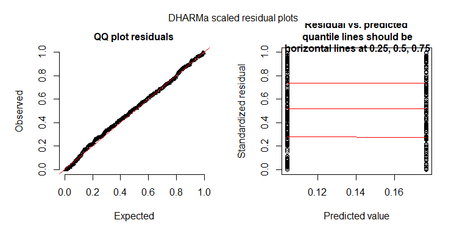

```r
sim_m_con_f_3 <- simulateResiduals(fittedModel = m_con_f_3$full_model, n = 250)
plotSimulatedResiduals(sim_m_con_f_3)
```

Interestingly, only for the optimal model but not for the maximal model is the effetc of Fit significant.

```r
nice(m_con_f_1)
```

```
Mixed Model Anova Table (Type 3 tests, LRT-method)

Model: Consequent ~ Fit + (Fit | P.s) + (Fit | Item)
Data: drp_r
Df full model: 8
  Effect df Chisq p.value
1    Fit  1  0.88     .35
---
Signif. codes:  0 *** 0.001 ** 0.01 * 0.05 + 0.1   1
```

```r
nice(m_con_f_3)
```

```
Mixed Model Anova Table (Type 3 tests, LRT-method)

Model: Consequent ~ Fit + (1 | P.s) + (Fit || Item)
Data: drp_r
Df full model: 5
  Effect df  Chisq p.value
1    Fit  1 3.88 *     .05
---
Signif. codes:  0 *** 0.001 ** 0.01 * 0.05 + 0.1   1
```

## With Accepts (non-transformed)

```r
m_con_a_1 <- mixed(Consequent ~ acc_z + (acc_z|P.s) + (Fit| Item), drp_r, family = binomial, method = "LRT", progress = FALSE)
```

```
Contrasts set to contr.sum for the following variables: P.s, Fit, Item
```

```r
summary(m_con_a_1)
```

```
Generalized linear mixed model fit by maximum likelihood (Laplace Approximation) ['glmerMod']
 Family: binomial  ( logit )
Formula: Consequent ~ acc_z + (acc_z | P.s) + (Fit | Item)
   Data: drp_r

     AIC      BIC   logLik deviance df.resid
   376.9    409.0   -180.5    360.9      400

Scaled residuals:
    Min      1Q  Median      3Q     Max
-0.9433 -0.4658 -0.3595 -0.2409  3.6991

Random effects:
 Groups Name        Variance Std.Dev. Corr
 P.s    (Intercept) 0.35378  0.5948
        acc_z       0.01017  0.1009   -1.00
 Item   (Intercept) 0.54238  0.7365
        Fit1        0.10168  0.3189   -1.00
Number of obs: 408, groups:  P.s, 24; Item, 17

Fixed effects:
            Estimate Std. Error z value Pr(>|z|)
(Intercept)  -1.9708     0.2790  -7.063 1.63e-12 ***
acc_z         0.1713     0.1670   1.025    0.305
---
Signif. codes:  0 *** 0.001 ** 0.01 * 0.05 . 0.1   1

Correlation of Fixed Effects:
      (Intr)
acc_z -0.235
```

We see a suspcisouly high correlations between for both random effect grouping factors, consequently we remove those.

```r
m_con_a_2 <- mixed(Consequent ~ acc_z + (acc_z||P.s) + (Fit|| Item), drp_r, family = binomial, method = "LRT", progress = FALSE, expand_re = TRUE, all_fit = TRUE)
```

```
Contrasts set to contr.sum for the following variables: P.s, Fit, Item
Model failed to converge with max|grad| = 0.0478086 (tol = 0.001, component 1)Model failed to converge with max|grad| = 0.0466522 (tol = 0.001, component 1)
```

```r
summary(m_con_a_2)
```

```
Generalized linear mixed model fit by maximum likelihood (Laplace Approximation) ['glmerMod']
 Family: binomial  ( logit )
Formula: Consequent ~ acc_z + (1 + re1.acc_z || P.s) + (1 + re2.Fit1 ||      Item)
   Data: drp_r

     AIC      BIC   logLik deviance df.resid
   375.8    399.9   -181.9    363.8      402

Scaled residuals:
    Min      1Q  Median      3Q     Max
-0.8395 -0.4619 -0.3687 -0.2514  3.3054

Random effects:
 Groups Name        Variance  Std.Dev.
 P.s    (Intercept) 3.033e-01 0.5507560
 P.s.1  re1.acc_z   1.195e-07 0.0003457
 Item   (Intercept) 5.020e-01 0.7084926
 Item.1 re2.Fit1    1.115e-01 0.3339860
Number of obs: 408, groups:  P.s, 24; Item, 17

Fixed effects:
             Estimate Std. Error z value Pr(>|z|)
(Intercept) -1.852050   0.001480 -1251.3   <2e-16 ***
acc_z        0.132380   0.001479    89.5   <2e-16 ***
---
Signif. codes:  0 *** 0.001 ** 0.01 * 0.05 . 0.1   1

Correlation of Fixed Effects:
      (Intr)
acc_z 0.000
convergence code: 0
Model failed to converge with max|grad| = 0.0478086 (tol = 0.001, component 1)
```

Given the small estimate of the by-participant random slope we remove it.

```r
m_con_a_3 <- mixed(Consequent ~ acc_z + (1|P.s) + (Fit|| Item), drp_r, family = binomial, method = "LRT", progress = FALSE, expand_re = TRUE, all_fit = TRUE)
```

```
Contrasts set to contr.sum for the following variables: P.s, Fit, Item
Model failed to converge with max|grad| = 0.0477961 (tol = 0.001, component 1)Model failed to converge with max|grad| = 0.0466512 (tol = 0.001, component 1)
```

```r
summary(m_con_a_3)
```

```
Generalized linear mixed model fit by maximum likelihood (Laplace Approximation) ['glmerMod']
 Family: binomial  ( logit )
Formula: Consequent ~ acc_z + (1 | P.s) + (1 + re2.Fit1 || Item)
   Data: drp_r
Control: ctrl

     AIC      BIC   logLik deviance df.resid
   373.8    393.9   -181.9    363.8      403

Scaled residuals:
    Min      1Q  Median      3Q     Max
-0.8395 -0.4619 -0.3687 -0.2514  3.3045

Random effects:
 Groups Name        Variance Std.Dev.
 P.s    (Intercept) 0.3035   0.5509
 Item   (Intercept) 0.5012   0.7080
 Item.1 re2.Fit1    0.1117   0.3343
Number of obs: 408, groups:  P.s, 24; Item, 17

Fixed effects:
             Estimate Std. Error z value Pr(>|z|)
(Intercept) -1.852075   0.001480 -1251.5   <2e-16 ***
acc_z        0.132253   0.001479    89.4   <2e-16 ***
---
Signif. codes:  0 *** 0.001 ** 0.01 * 0.05 . 0.1   1

Correlation of Fixed Effects:
      (Intr)
acc_z 0.000
convergence code: 0
Model failed to converge with max|grad| = 0.0478054 (tol = 0.001, component 1)
```

```r
anova(m_con_a_1, m_con_a_2, m_con_a_3)
```

```
Data: drp_r
Models:
m_con_a_3: Consequent ~ acc_z + (1 | P.s) + (1 + re2.Fit1 || Item)
m_con_a_2: Consequent ~ acc_z + (1 + re1.acc_z || P.s) + (1 + re2.Fit1 ||
m_con_a_2:     Item)
m_con_a_1: Consequent ~ acc_z + (acc_z | P.s) + (Fit | Item)
          Df    AIC    BIC  logLik deviance  Chisq Chi Df Pr(>Chisq)
m_con_a_3  5 373.83 393.89 -181.91   363.83
m_con_a_2  6 375.83 399.90 -181.91   363.83 0.0000      1     1.0000
m_con_a_1  8 376.94 409.03 -180.47   360.94 2.8905      2     0.2357
```

Again, the reduced model seems to be the optimal model. Consequently we also inspect the residuals of this model. Overall this also looks very reasonable.

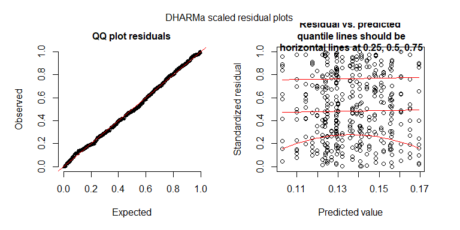

```r
sim_m_con_a_3 <- simulateResiduals(fittedModel = m_con_a_3$full_model, n = 500)
plotSimulatedResiduals(sim_m_con_a_3)
```

Interestingly, neither model shows a significant effect of `Accepts` (z-transformed to `acc_z`).

```r
nice(m_con_a_1)
```

```
Mixed Model Anova Table (Type 3 tests, LRT-method)

Model: Consequent ~ acc_z + (acc_z | P.s) + (Fit | Item)
Data: drp_r
Df full model: 8
  Effect df Chisq p.value
1  acc_z  1  1.06     .30
---
Signif. codes:  0 *** 0.001 ** 0.01 * 0.05 + 0.1   1
```

```r
nice(m_con_a_3)
```

```
Mixed Model Anova Table (Type 3 tests, LRT-method)

Model: Consequent ~ acc_z + (1 | P.s) + (Fit || Item)
Data: drp_r
Df full model: 5
  Effect df Chisq p.value
1  acc_z  1  0.72     .40
---
Signif. codes:  0 *** 0.001 ** 0.01 * 0.05 + 0.1   1
```

This contrasts somewhat with the results of the Wald tests reported above which clearly show a significant effect of `acc_z`. Consequently, we repeated the analysis using parametric bootstrap. This also showed no effect of `acc_z`.

```r
nice(m_con_a_3_pb)
```

```
Mixed Model Anova Table (Type 3 tests, PB-method)

Model: Consequent ~ acc_z + (1 | P.s) + (Fit || Item)
Data: drp_r
  Effect df Chisq p.value
1  acc_z  1  0.72     .39
---
Signif. codes:  0 *** 0.001 ** 0.01 * 0.05 + 0.1   1
```

If we plot the estimated effect we can see that it indeed is small.

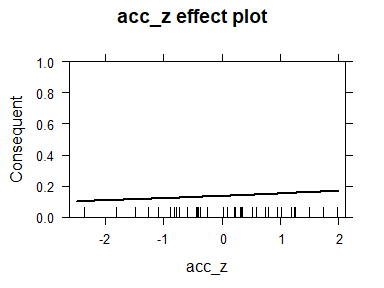

# Spillover

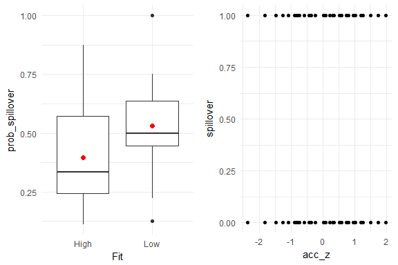

```r
p_obs_acc <- ggplot(data = drp_r, aes(x = acc_z, y = spillover)) +
  geom_point()
p_obs_fit <- ggplot(agg, aes(x = Fit, y = prob_spillover)) +
  geom_boxplot() +
   stat_summary(fun.y = "mean", colour = "red", size = 2, geom = "point")
grid.arrange(p_obs_fit, p_obs_acc, ncol = 2)
```

## With Fit

```r
m_spill_f_1 <- mixed(spillover ~ Fit + (Fit|P.s) + (Fit| Item), drp_r, family = binomial, method = "LRT", progress = FALSE)
```

```
Contrasts set to contr.sum for the following variables: Fit, P.s, Item
```

```r
summary(m_spill_f_1)
```

```
Generalized linear mixed model fit by maximum likelihood (Laplace Approximation) ['glmerMod']
 Family: binomial  ( logit )
Formula: spillover ~ Fit + (Fit | P.s) + (Fit | Item)
   Data: drp_r

     AIC      BIC   logLik deviance df.resid
   557.2    589.3   -270.6    541.2      400

Scaled residuals:
    Min      1Q  Median      3Q     Max
-1.5340 -0.8306 -0.5507  0.9246  2.0041

Random effects:
 Groups Name        Variance Std.Dev. Corr
 P.s    (Intercept) 0.425704 0.65246
        Fit1        0.004814 0.06938  1.00
 Item   (Intercept) 0.047932 0.21893
        Fit1        0.015270 0.12357  -1.00
Number of obs: 408, groups:  P.s, 24; Item, 17

Fixed effects:
            Estimate Std. Error z value Pr(>|z|)
(Intercept)  -0.1659     0.1787  -0.928  0.35338
Fit1         -0.3037     0.1115  -2.723  0.00646 **
---
Signif. codes:  0 *** 0.001 ** 0.01 * 0.05 . 0.1   1

Correlation of Fixed Effects:
     (Intr)
Fit1 0.035
```

Due to the large correlation between the by-participants and by-item random-effects parameters we refit the model without the correlations.

```r
m_spill_f_2 <- mixed(spillover ~ Fit + (Fit||P.s) + (Fit|| Item), drp_r, family = binomial, method = "LRT", progress = FALSE, expand_re = TRUE)
```

```
Contrasts set to contr.sum for the following variables: Fit, P.s, Item
```

```r
summary(m_spill_f_2)
```

```
Generalized linear mixed model fit by maximum likelihood (Laplace Approximation) ['glmerMod']
 Family: binomial  ( logit )
Formula: spillover ~ Fit + (1 + re1.Fit1 || P.s) + (1 + re2.Fit1 || Item)
   Data: drp_r

     AIC      BIC   logLik deviance df.resid
   554.2    578.3   -271.1    542.2      402

Scaled residuals:
    Min      1Q  Median      3Q     Max
-1.5001 -0.8378 -0.5687  0.9760  1.9019

Random effects:
 Groups Name        Variance Std.Dev.
 P.s    (Intercept) 0.41982  0.6479
 P.s.1  re1.Fit1    0.00000  0.0000
 Item   (Intercept) 0.02023  0.1422
 Item.1 re2.Fit1    0.00000  0.0000
Number of obs: 408, groups:  P.s, 24; Item, 17

Fixed effects:
            Estimate Std. Error z value Pr(>|z|)
(Intercept)  -0.1611     0.1725  -0.934  0.35041
Fit1         -0.3006     0.1059  -2.838  0.00454 **
---
Signif. codes:  0 *** 0.001 ** 0.01 * 0.05 . 0.1   1

Correlation of Fixed Effects:
     (Intr)
Fit1 0.014
```

Now both random slopes are estimated to be zero, we consequently refit the model without those parameters.

```r
m_spill_f_3 <- mixed(spillover ~ Fit + (1|P.s) + (1| Item), drp_r, family = binomial, method = "LRT", progress = FALSE)
```

```
Contrasts set to contr.sum for the following variables: Fit, P.s, Item
```

```r
summary(m_spill_f_3)
```

```
Generalized linear mixed model fit by maximum likelihood (Laplace Approximation) ['glmerMod']
 Family: binomial  ( logit )
Formula: spillover ~ Fit + (1 | P.s) + (1 | Item)
   Data: drp_r

     AIC      BIC   logLik deviance df.resid
   550.2    566.3   -271.1    542.2      404

Scaled residuals:
    Min      1Q  Median      3Q     Max
-1.5001 -0.8378 -0.5687  0.9760  1.9019

Random effects:
 Groups Name        Variance Std.Dev.
 P.s    (Intercept) 0.41981  0.6479
 Item   (Intercept) 0.02023  0.1422
Number of obs: 408, groups:  P.s, 24; Item, 17

Fixed effects:
            Estimate Std. Error z value Pr(>|z|)
(Intercept)  -0.1611     0.1725  -0.934  0.35043
Fit1         -0.3006     0.1059  -2.838  0.00454 **
---
Signif. codes:  0 *** 0.001 ** 0.01 * 0.05 . 0.1   1

Correlation of Fixed Effects:
     (Intr)
Fit1 0.014
```

This model seems reasonable and only provides a minimally worse account than the first model.

```r
anova(m_spill_f_1, m_spill_f_3)
```

```
Data: drp_r
Models:
m_spill_f_3: spillover ~ Fit + (1 | P.s) + (1 | Item)
m_spill_f_1: spillover ~ Fit + (Fit | P.s) + (Fit | Item)
            Df    AIC    BIC  logLik deviance  Chisq Chi Df Pr(>Chisq)
m_spill_f_3  4 550.21 566.26 -271.11   542.21
m_spill_f_1  8 557.23 589.32 -270.62   541.23 0.9785      4      0.913
```

The diagnistic plots look again regularly.

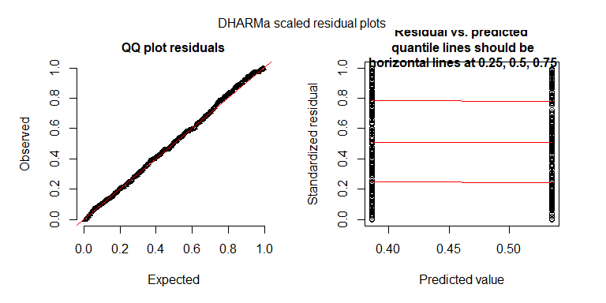

```r
sim_m_spill_f_3 <- simulateResiduals(fittedModel = m_spill_f_3$full_model, n = 500)
plotSimulatedResiduals(sim_m_spill_f_3)
```

The effect of Fit is significant for all models.

```r
nice(m_spill_f_1)
```

```
Mixed Model Anova Table (Type 3 tests, LRT-method)

Model: spillover ~ Fit + (Fit | P.s) + (Fit | Item)
Data: drp_r
Df full model: 8
  Effect df   Chisq p.value
1    Fit  1 6.90 **    .009
---
Signif. codes:  0 *** 0.001 ** 0.01 * 0.05 + 0.1   1
```

```r
nice(m_spill_f_3)
```

```
Mixed Model Anova Table (Type 3 tests, LRT-method)

Model: spillover ~ Fit + (1 | P.s) + (1 | Item)
Data: drp_r
Df full model: 4
  Effect df   Chisq p.value
1    Fit  1 8.18 **    .004
---
Signif. codes:  0 *** 0.001 ** 0.01 * 0.05 + 0.1   1
```

## With Accepts (non-transformed)

```r
m_spill_a_1 <- mixed(spillover ~ acc_z + (acc_z|P.s) + (Fit| Item), drp_r, family = binomial, method = "LRT", progress = FALSE)
```

```
Contrasts set to contr.sum for the following variables: P.s, Fit, Item
```

```r
summary(m_spill_a_1)
```

```
Generalized linear mixed model fit by maximum likelihood (Laplace Approximation) ['glmerMod']
 Family: binomial  ( logit )
Formula: spillover ~ acc_z + (acc_z | P.s) + (Fit | Item)
   Data: drp_r

     AIC      BIC   logLik deviance df.resid
   562.3    594.4   -273.2    546.3      400

Scaled residuals:
    Min      1Q  Median      3Q     Max
-1.5382 -0.8240 -0.5984  0.9461  1.8979

Random effects:
 Groups Name        Variance Std.Dev. Corr
 P.s    (Intercept) 0.400159 0.63258
        acc_z       0.002182 0.04671  1.00
 Item   (Intercept) 0.066949 0.25875
        Fit1        0.069192 0.26304  -1.00
Number of obs: 408, groups:  P.s, 24; Item, 17

Fixed effects:
            Estimate Std. Error z value Pr(>|z|)
(Intercept)  -0.2389     0.1847  -1.294    0.196
acc_z        -0.1662     0.1197  -1.389    0.165

Correlation of Fixed Effects:
      (Intr)
acc_z 0.083
```

Again we observe large correlations between the by-participants and by-item random-effects parameters and we refit the model without the correlations.

```r
m_spill_a_2 <- mixed(spillover ~ acc_z + (acc_z||P.s) + (Fit|| Item), drp_r, family = binomial, method = "LRT", progress = FALSE, expand_re = TRUE)
```

```
Contrasts set to contr.sum for the following variables: P.s, Fit, Item
```

```r
summary(m_spill_a_2)
```

```
Generalized linear mixed model fit by maximum likelihood (Laplace Approximation) ['glmerMod']
 Family: binomial  ( logit )
Formula: spillover ~ acc_z + (1 + re1.acc_z || P.s) + (1 + re2.Fit1 ||      Item)
   Data: drp_r

     AIC      BIC   logLik deviance df.resid
   560.5    584.6   -274.2    548.5      402

Scaled residuals:
    Min      1Q  Median      3Q     Max
-1.6123 -0.8330 -0.6273  0.9755  1.6857

Random effects:
 Groups Name        Variance Std.Dev.
 P.s    (Intercept) 0.37440  0.6119
 P.s.1  re1.acc_z   0.00000  0.0000
 Item   (Intercept) 0.01419  0.1191
 Item.1 re2.Fit1    0.02426  0.1558
Number of obs: 408, groups:  P.s, 24; Item, 17

Fixed effects:
            Estimate Std. Error z value Pr(>|z|)
(Intercept)  -0.1583     0.1654  -0.957    0.339
acc_z        -0.1567     0.1170  -1.339    0.180

Correlation of Fixed Effects:
      (Intr)
acc_z 0.002
```

Aa one random slopes is estimated to be zero, we consequently refit the model without this parameter.

```r
m_spill_a_3 <- mixed(spillover ~ acc_z + (1|P.s) + (Fit|| Item), drp_r, family = binomial, method = "LRT", progress = FALSE, expand_re = TRUE)
```

```
Contrasts set to contr.sum for the following variables: P.s, Fit, Item
```

```r
summary(m_spill_a_3)
```

```
Generalized linear mixed model fit by maximum likelihood (Laplace Approximation) ['glmerMod']
 Family: binomial  ( logit )
Formula: spillover ~ acc_z + (1 | P.s) + (1 + re2.Fit1 || Item)
   Data: drp_r

     AIC      BIC   logLik deviance df.resid
   558.5    578.6   -274.2    548.5      403

Scaled residuals:
    Min      1Q  Median      3Q     Max
-1.6123 -0.8330 -0.6273  0.9755  1.6857

Random effects:
 Groups Name        Variance Std.Dev.
 P.s    (Intercept) 0.37440  0.6119
 Item   (Intercept) 0.01419  0.1191
 Item.1 re2.Fit1    0.02427  0.1558
Number of obs: 408, groups:  P.s, 24; Item, 17

Fixed effects:
            Estimate Std. Error z value Pr(>|z|)
(Intercept)  -0.1583     0.1654  -0.957    0.339
acc_z        -0.1567     0.1170  -1.339    0.180

Correlation of Fixed Effects:
      (Intr)
acc_z 0.002
```

This model seems reasonable and only provides a minimally worse account than the first model.

```r
anova(m_spill_a_1, m_spill_a_3)
```

```
Data: drp_r
Models:
m_spill_a_3: spillover ~ acc_z + (1 | P.s) + (1 + re2.Fit1 || Item)
m_spill_a_1: spillover ~ acc_z + (acc_z | P.s) + (Fit | Item)
            Df    AIC    BIC  logLik deviance  Chisq Chi Df Pr(>Chisq)
m_spill_a_3  5 558.50 578.56 -274.25   548.50
m_spill_a_1  8 562.35 594.44 -273.17   546.35 2.1522      3     0.5414
```

No issue with the diagnostic plots.

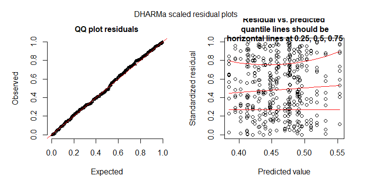

```r
sim_m_spill_a_3 <- simulateResiduals(fittedModel = m_spill_a_3$full_model, n = 500)
plotSimulatedResiduals(sim_m_spill_a_3)
```

The effect of `acc_z` is not significant in either model.

```r
nice(m_spill_a_1)
```

```
Mixed Model Anova Table (Type 3 tests, LRT-method)

Model: spillover ~ acc_z + (acc_z | P.s) + (Fit | Item)
Data: drp_r
Df full model: 8
  Effect df Chisq p.value
1  acc_z  1  1.93     .16
---
Signif. codes:  0 *** 0.001 ** 0.01 * 0.05 + 0.1   1
```

```r
nice(m_spill_a_3)
```

```
Mixed Model Anova Table (Type 3 tests, LRT-method)

Model: spillover ~ acc_z + (1 | P.s) + (Fit || Item)
Data: drp_r
Df full model: 5
  Effect df Chisq p.value
1  acc_z  1  1.79     .18
---
Signif. codes:  0 *** 0.001 ** 0.01 * 0.05 + 0.1   1
```